# CAPSTONE PROJECT

Rajashree

2024-07-05

In this we do Differential gene expression analysis with NCBI GEO GSE200306 dataset . The glomeruli tissues of stage 3 stage 4 and control samples for lupus nephritis were considered for analysis to find the genes involved in calcineurin activation pathway causing abnormal Tcell proliferation and further leading to autoimmune condition that affect the glomeruli filtration and kidney failure .

The analysis was done using R Studio

The necessary libraries were loaded in installed and loaded in R

```r
library(Biobase)
library(limma)
library(RColorBrewer)
library(dplyr)
```

```r
library(ggplot2)
library(geneplotter)
library(pheatmap)
library(enrichplot)
library(tidyr)
library(EnhancedVolcano)
library(clusterProfiler)
library(GEOquery)
library(umap)
library(AnnotationDbi)
```

the working directory was set to the directory capstone project

```r
 setwd("C:/Users/rajas/OneDrive/Documents/capstoneproject")
```

**phenodata**

The data such as phenoData containing the sample information,exprsData containing the genes or factors expression information for each sample and the featureData with gene annotation data, gene sequence, genebank accession etc. were obtained with the code below

```r
#phenodata

gse <- getGEO(filename = "C:/Users/rajas/OneDrive/Documents/capstoneproject/GSE200306_series_matrix.txt",GSEMatrix = TRUE)
phenoData <- pData(gse)
```

```r
#modify rownames as geo_accession
rownames(phenoData) <- phenoData$geo_accession

# to add column with sample_id unique to each sample mentioned in expressiondata columns
phenoData_title <- dplyr::select(phenoData, title)

# Extract the desired information using pattern matching and substitution:
phenoData_extracted <- sub(".*\\[(.*)\\].*", "\\1", phenoData_title$title)
phenoData_extracted<- data.frame(title = phenoData_extracted, row.names = rownames(phenoData_title))
phenoData_extracted<-phenoData_extracted %>% dplyr::rename(sample_id=title)


## Extract patient information using regular expressions:
patient_info <- sub("^(.*?),.*", "\\1",phenoData_title$title)

##Print the extracted patient information:
patient_info<- data.frame(title = patient_info, row.names = rownames(phenoData_title))
patient_info<-patient_info %>% dplyr::rename(patient_info=title)


#add sample_id from phenoData_extracted to phenoData datframe

phenoData$sample_id <- phenoData_extracted$sample_id
phenoData$patient_info <- patient_info$patient_info
phenoData <-relocate(phenoData,geo_accession, .before = 1)
phenoData <- relocate(phenoData, sample_id, .before = 2)
phenoData <- relocate(phenoData, characteristics_ch1, .before = 3)


library(S4Vectors)
phenoData <- head(phenoData, 79)
phenoData_mixed<-phenoData %>% filter(grepl("ln class: Mixed \\(III/IV\\+V\\)", characteristics_ch1))

#rownames(phenoData_mixed)

phenoData<- phenoData %>% filter(!grepl("ln class: Mixed \\(III/IV\\+V\\)", characteristics_ch1))

phenoData<-phenoData[ ,c(1:4,42)]

phenoData <- mutate(phenoData,
                    stages = case_when(
                      characteristics_ch1 == "ln class: Class IV" ~ "stage4",
                      characteristics_ch1 == "ln class: Class III" ~ "stage3",
                      TRUE ~ "control"  # Default label for other values
                    )
)
```

**exprsdata**

normalised.expressDatagl obtained from supplementary file provided for GSE200306 dataset from NCBI, has 158 columns of sample and 3 other columns with gene-name in one such column modify to make gene_name as rows and samples in column.

```r
normalised.expressDatagl <- read.delim("C:/Users/rajas/OneDrive/Documents/capstoneproject/GSE200306_normalized_Glom_expression_data.txt")

first_column <- normalised.expressDatagl$Name

rownames(normalised.expressDatagl) <- first_column

normalised.expressDatagl<- normalised.expressDatagl %>%
  dplyr::select(-Name,-Accession, -Code.Class)


exprsData<- normalised.expressDatagl

#remove column of mixed and other normalisation colums from normalised.expressionDatagl
exprsData<- select(exprsData,
                   -X7a_7 , -X12A_8, -X15A_5 ,-X23A_9,-X32A,-X10A,-X7b_7,-X15B_5,-X10B ,-X24B , -X4B_7 , -X16b_9,
                    -CR1_mean, -CR2_mean,-NORM_mean,-NR1_mean,-NR2_mean,-PR1_mean,-PR2_mean,-CR1_vs_Normal_est,
                    -NR1_vs_Normal_est,  - PR1_vs_Normal_est,-CR2_vs_Normal_est,-NR2_vs_Normal_est,-PR2_vs_Normal_est,
                    -CR2_vs_CR1_est,-NR2_vs_NR1_est,-PR2_vs_PR1_est,-CR1_vs_NR1_est,
                    -CR2_vs_NR2_est,-CR1_vs_PR1_est,-CR2_vs_PR2_est,-PR1_vs_NR1_est,
                    -PR2_vs_NR2_est,-CR2_1_vs_NR2_1_est,-CR2_1_vs_PR2_1_est,-NR2_1_vs_PR2_1_est,
                    -fold.CR1_vs_Normal_est,-p.CR1_vs_Normal_est,-fold.NR1_vs_Normal_est,-p.NR1_vs_Normal_est,
                    -fold.PR1_vs_Normal_est,-p.PR1_vs_Normal_est,-fold.CR2_vs_Normal_est,-p.CR2_vs_Normal_est,
                    -fold.NR2_vs_Normal_est,-p.NR2_vs_Normal_est,-fold.PR2_vs_Normal_est,-p.PR2_vs_Normal_est,
                    -fold.CR2_vs_CR1_est,-p.CR2_vs_CR1_est,-fold.NR2_vs_NR1_est,-p.NR2_vs_NR1_est,
                    -fold.PR2_vs_PR1_est,-p.PR2_vs_PR1_est,-fold.CR1_vs_NR1_est,-p.CR1_vs_NR1_est,
                    -fold.CR2_vs_NR2_est,-p.CR2_vs_NR2_est,-fold.CR1_vs_PR1_est,-p.CR1_vs_PR1_est,
                    -fold.CR2_vs_PR2_est,-p.CR2_vs_PR2_est,-fold.PR1_vs_NR1_est,-p.PR1_vs_NR1_est,
                    -fold.PR2_vs_NR2_est,-p.PR2_vs_NR2_est,-fold.CR2_1_vs_NR2_1_est,-p.CR2_1_vs_NR2_1_est,
                    -fold.CR2_1_vs_PR2_1_est,-p.CR2_1_vs_PR2_1_est,-fold.NR2_1_vs_PR2_1_est,-p.NR2_1_vs_PR2_1_est,
                    -flag.CR1_vs_Normal,-flag.NR1_vs_Normal,-flag.PR1_vs_Normal,-flag.CR2_vs_Normal,
                    -flag.NR2_vs_Normal,-flag.PR2_vs_Normal,-flag.CR2_vs_CR1,-flag.NR2_vs_NR1,
                    -flag.PR2_vs_PR1,-flag.CR1_vs_NR1,-flag.CR2_vs_NR2,-flag.CR1_vs_PR1,
                    -flag.CR2_vs_PR2,-flag.PR1_vs_NR1,-flag.PR2_vs_NR2,-flag.CR2_1_vs_NR2_1,
                    -flag.CR2_1_vs_PR2_1,-flag.NR2_1_vs_PR2_1)

#to change column names in exprsData from sample_id to respective geo_accession number

old_names <- c("X1A.G_3" ,"X02A_5" ,"X06A_1" ,"X11A_5" ,"X20a_8","X26A_2","X30A","X37A_5","X39A_1","X48a_9",
               "X49A_10","X50A_10","X51A_7","X55A_9","X58a_8","X5a_7","X13A","X17a_7","X24A","X27A_9",
               "X38A.G_3","X14a_8","X18A_2","X21A_1","X22A_10","X28A_1","X35A_2","X56A_10","X1B.G_3","X02B_5",
               "X11B_5","X19B_2","X20b_8","X23B_9","X26B_2","X30B","X32B","X37B_5","X39B_1","X48b_9",
                "X49B_10","X50B_10","X51B_7","X53B_1","X55B_9","X58b_8","X05B","X13B","X17B","X27B",
                "X31B_8","X38B.G_3","X14b_8","X18B_2","X21B_1","X22B_10","X28B_1","X56B_10","X1XN_10","X2XN_10",
                 "X3XNG_1","X4XNG_1","X5XNG1_2","X7XNG_2","X10Y","X15Y","X16Y")

new_names<- c("GSM6030648","GSM6030649","GSM6030650","GSM6030652","GSM6030655","GSM6030657",
              "GSM6030658","GSM6030660","GSM6030661","GSM6030662","GSM6030663","GSM6030664",
              "GSM6030665","GSM6030666","GSM6030667","GSM6030668","GSM6030670","GSM6030671",
              "GSM6030672","GSM6030673","GSM6030674","GSM6030675","GSM6030676","GSM6030677",
              "GSM6030678","GSM6030679","GSM6030680","GSM6030681","GSM6030682","GSM6030683",
              "GSM6030685","GSM6030687","GSM6030688","GSM6030689","GSM6030690","GSM6030691",
              "GSM6030692","GSM6030693","GSM6030694","GSM6030695","GSM6030696","GSM6030697",
              "GSM6030698","GSM6030699","GSM6030700","GSM6030701","GSM6030702","GSM6030704",
              "GSM6030705","GSM6030707","GSM6030708","GSM6030709","GSM6030711","GSM6030713",
              "GSM6030714","GSM6030715","GSM6030716","GSM6030717","GSM6030718","GSM6030719",
              "GSM6030720","GSM6030721","GSM6030722","GSM6030723","GSM6030724","GSM6030725","GSM6030726")


# Check if entries are present in column names

present_cols <- old_names %in% names(exprsData)

# Print results

if (any(present_cols)) {
 cat("Entries present as column names:", old_names[present_cols], sep = ", ")
} else {
 print("No entries from the list are present as column names.")
}
```

```
## Entries present as column names:, X1A.G_3, X02A_5, X06A_1, X11A_5, X20a_8, X26A_2, X30A, X37A_5, X39A_1, X48a_9, X49A_10, X50A_10, X51A_7, X55A_9, X58a_8, X5a_7, X13A, X17a_7, X24A, X27A_9, X38A.G_3, X14a_8, X18A_2, X21A_1, X22A_10, X28A_1, X35A_2, X56A_10, X1B.G_3, X02B_5, X11B_5, X19B_2, X20b_8…
```

```r
# TO get matching and not matchimg ones

matching_cols <- old_names[old_names %in% names(exprsData)]

matching_cols <- old_names[!old_names %in% names(exprsData)]

#Arrange exprsData columns in order like in old names

head(exprsData)
```

```
##       X53B_1 X06A_1 X39A_1 X39B_1 X21A_1 X28A_1 X3XNG_1 X4XNG_1 X21B_1 X28B_1
## ABCB1   3.92   3.70   3.58   3.85   5.53   3.35    4.16    2.82   3.68   3.39
## ABL1    3.06   3.55   3.17   4.02   3.18   3.28    4.10    3.77   3.91   3.44
## ADA     5.01   4.39   3.17   4.67   4.37   4.38    4.54    4.63   4.13   4.56
## AHR     5.94   5.48   5.74   5.80   6.54   6.08    6.03    5.97   5.64   5.93
## AIRE    5.61   4.30   5.49   5.88   4.63   5.26    4.82    5.29   5.26   5.78
## APP     5.76   7.35   6.75   7.98   7.39   7.27    8.14    7.92   7.71   6.70
##       X18B_2 X19B_2 X26A_2 X26B_2 X35A_2 X18A_2 X7XNG_2 X5XNG1_2 X1A.G_3
## ABCB1   3.13   3.52   3.73   3.86   5.08   4.18    3.08     4.07    3.18
## ABL1    5.28   4.51   3.10   3.18   4.24   3.11    3.83     3.87    3.42
## ADA     3.73   3.86   4.09   3.62   3.76   3.20    4.25     4.35    4.78
## AHR     6.86   5.19   5.68   5.22   5.95   6.31    5.62     5.60    6.36
## AIRE    5.28   5.19   4.09   4.98   5.37   5.12    5.12     5.08    4.04
## APP     7.47   8.56   6.72   7.56   7.22   7.31    7.75     7.98    6.96
##       X1B.G_3 X38A.G_3 X38B.G_3 X02A_5 X37A_5 X37B_5 X11A_5 X02B_5 X11B_5 X5a_7
## ABCB1    3.40     3.33     5.41   2.99   4.29   3.42   4.30   3.82   3.82  2.69
## ABL1     3.61     3.15     2.81   3.92   3.89   3.63   3.50   3.32   4.26  4.07
## ADA      4.87     5.78     5.53   4.27   5.21   5.59   5.92   4.60   4.71  4.67
## AHR      6.31     7.13     7.04   5.74   6.26   6.08   5.95   6.51   5.82  6.26
## AIRE     5.00     5.33     4.71   3.73   5.43   4.65   4.53   3.56   3.26  4.67
## APP      6.88     5.73     7.98   7.47   5.76   7.17   6.33   7.98   6.26  8.44
##       X17a_7 X51B_7 X51A_7 X14b_8 X20a_8 X20b_8 X58b_8 X31B_8 X14a_8 X58a_8
## ABCB1   6.24   3.91   4.53   4.00   4.24   4.67   3.36   5.37   4.48   3.96
## ABL1    3.93   3.21   4.86   3.71   3.95   4.30   4.03   4.06   4.73   4.07
## ADA     4.33   5.61   3.29   4.00   3.72   4.02   3.73   4.06   3.53   3.96
## AHR     5.95   6.50   5.70   5.88   6.63   6.10   5.86   6.01   5.87   6.03
## AIRE    4.78   5.64   3.89   3.19   4.68   3.71   5.23   4.17   4.56   4.07
## APP     7.98   5.09   7.43   6.98   7.20   7.64   6.90   7.66   8.24   7.98
##       X55A_9 X23B_9 X27A_9 X48a_9 X55B_9 X48b_9 X50B_10 X49B_10 X50A_10 X49A_10
## ABCB1   4.32   4.59   7.56   4.18   4.43   3.94    4.23    3.09    4.05    4.16
## ABL1    4.16   3.60   4.56   3.69   3.72   3.74    4.79    4.26    4.05    4.21
## ADA     3.68   3.95   3.00   5.10   3.44   3.22    4.70    3.74    4.05    3.59
## AHR     6.05   5.86   6.31   5.58   6.31   6.01    5.56    6.17    5.35    5.62
## AIRE    3.68   4.59   5.30   4.95   4.62   5.43    5.64    5.51    5.60    4.80
## APP     5.77   7.75   5.05   6.53   6.90   7.39    7.75    6.33    5.60    7.47
##       X2XN_10 X22A_10 X22B_10 X56A_10 X56B_10 X1XN_10 X05B X10Y X13A X13B X15Y
## ABCB1    3.68    3.77    6.56    3.33    2.79    3.35 3.75 3.88 3.89 3.32 4.33
## ABL1     4.30    3.77    3.41    3.20    3.62    3.51 3.58 3.84 4.21 4.87 3.90
## ADA      3.78    4.05    4.42    4.49    4.03    4.56 4.12 4.06 4.21 2.67 3.63
## AHR      5.68    5.89    5.88    6.72    5.93    5.92 6.12 5.79 5.89 5.66 5.84
## AIRE     4.73    5.07    3.41    5.98    6.14    4.73 5.47 5.14 5.24 4.18 4.77
## APP      7.86    7.83    7.92    5.12    5.13    8.05 6.79 7.23 6.96 8.24 7.95
##       X16Y X17B X24A X27B X30A X30B X32B
## ABCB1 4.56 4.36 3.92 4.07 4.09 8.14 4.05
## ABL1  3.69 4.28 4.04 2.75 3.69 4.45 3.84
## ADA   3.50 3.95 3.61 4.12 4.29 3.60 4.34
## AHR   5.66 6.10 5.83 5.69 5.59 5.53 5.93
## AIRE  4.72 3.49 4.41 4.48 4.01 3.39 4.83
## APP   8.06 7.55 8.14 7.53 7.61 7.78 7.80
```

```r
exprsData <- exprsData[, old_names]


# to rename multiple column names

colnames(exprsData)<-  c("GSM6030648","GSM6030649","GSM6030650","GSM6030652","GSM6030655","GSM6030657",
                         "GSM6030658","GSM6030660","GSM6030661","GSM6030662","GSM6030663","GSM6030664",
                         "GSM6030665","GSM6030666","GSM6030667","GSM6030668","GSM6030670","GSM6030671",
                         "GSM6030672","GSM6030673","GSM6030674","GSM6030675","GSM6030676","GSM6030677",
                         "GSM6030678","GSM6030679","GSM6030680","GSM6030681","GSM6030682","GSM6030683",
                         "GSM6030685","GSM6030687","GSM6030688","GSM6030689","GSM6030690","GSM6030691",
                         "GSM6030692","GSM6030693","GSM6030694","GSM6030695","GSM6030696","GSM6030697",
                         "GSM6030698","GSM6030699","GSM6030700","GSM6030701","GSM6030702","GSM6030704",
                         "GSM6030705","GSM6030707","GSM6030708","GSM6030709","GSM6030711","GSM6030713",
                         "GSM6030714","GSM6030715","GSM6030716","GSM6030717","GSM6030718","GSM6030719",
                         "GSM6030720","GSM6030721","GSM6030722","GSM6030723","GSM6030724","GSM6030725","GSM6030726")
```

From the exprsData it is already processed ,for nanostring data, raw counts were normalized to the positive spike-in controls and then log2 transformed. To reduce technical bias, genes with an expression level below the mean plus two standard deviations of the negative controls were filtered out. Quantile normalization was applied to the remaining transcripts (522 for glomeruli and 502 for TI).

**featuredata**

```r
gse <- getGEO( "GSE200306", GSEMatrix = TRUE)
```

```
## Found 1 file(s)
```

```
## GSE200306_series_matrix.txt.gz
```

```
## Using locally cached version of GPL21847 found here:
## C:\Users\rajas\AppData\Local\Temp\Rtmpgh3M4m/GPL21847.soft.gz
```

```r
#Get feature data

featureData <- gse$GSE200306_series_matrix.txt.gz@featureData@data

genes_to_remove <- c("BLNK", "C3", "C8B", "DPP4", "KIT")

featureData <- featureData[!rownames(featureData) %in% genes_to_remove, ]

View(featureData)

View(exprsData)## counts_data

View(phenoData)##sample_info
```

Create the ExpressionSet object

```r
gset<-ExpressionSet(as.matrix(exprsData))

pData(gset)<-phenoData

featureData(gset) <- as(featureData,"AnnotatedDataFrame")
```

log2 transformation

```r
ex <- exprs(gset)
qx <- as.numeric(quantile(ex, c(0., 0.25, 0.5, 0.75, 0.99, 1.0), na.rm=T))
LogC <- (qx[5] > 100) ||
  (qx[6]-qx[1] > 50 && qx[2] > 0)
if (LogC) { ex[which(ex <= 0)] <- NaN
exprs(gset) <- log2(ex) }
```

assign samples to groups and set up design matrix

```r
gs <- factor(phenoData$stages)
groups <- make.names(c("stage3","stage4","control"))
levels(gs) <- groups
gset$group <- gs
design <- model.matrix(~group + 0, gset)
colnames(design) <- levels(gs)

gset <- gset[complete.cases(exprs(gset)), ]
```

**visualisation-Exploratory Graph**

Before applying mulitiple testing on the data we should examine exploratory graphs like PCA and heatmaps to assesss our data. **PCA plot**

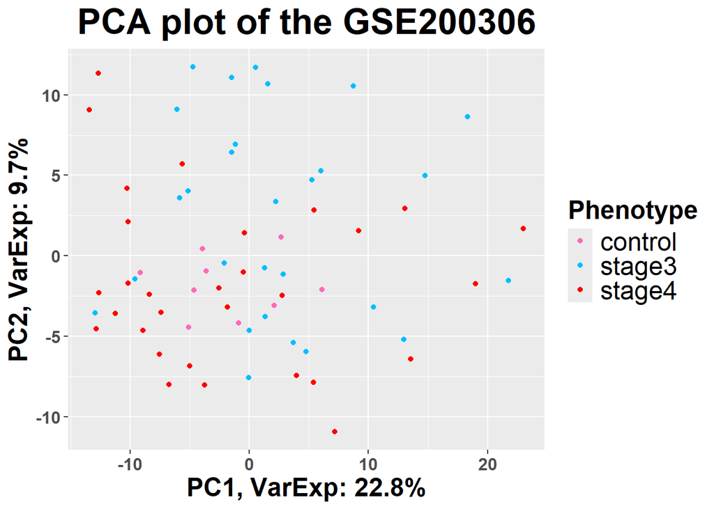

```r
fig <- function(width, heigth){
  options(repr.plot.width = width, repr.plot.height = heigth)
}

#Create a PCA plot examine the variation in the data by the phenotype variable of interest.

# Creates PCA Plots
fig(12,8)
GSE200306_exprs <- Biobase::exprs(gset)
PCA <- prcomp(t(GSE200306_exprs), scale = FALSE)
percentVar <- round(100*PCA$sdev^2/sum(PCA$sdev^2),1)
sd_ratio <- sqrt(percentVar[2] / percentVar[1])
dataGG <- data.frame(PC1 = PCA$x[,1], PC2 = PCA$x[,2],

                     Phenotype =
                       Biobase::pData(gset)$stages)

ggplot(dataGG, aes(PC1, PC2)) +
  geom_point(aes(colour = Phenotype)) +
  ggtitle("PCA plot of the GSE200306") +
  xlab(paste0("PC1, VarExp: ", percentVar[1], "%")) +
  ylab(paste0("PC2, VarExp: ", percentVar[2], "%")) +
  theme(plot.title = element_text(hjust = 0.5,size=25, face='bold'),
        axis.text.x = element_text(size=12, face='bold'),
        axis.text.y = element_text(size=12, face='bold'),
        axis.title.x = element_text(size=18, face='bold'),
        axis.title.y = element_text(size=18, face='bold'),
        legend.title = element_text(size=18, face='bold'),
        legend.text = element_text(size=18) ) +
  scale_color_manual(values = c("hotpink", "deepskyblue","red"))
```

The variance of PC1 and PC2 are 22.8% and 9.7% respectively. The points on the plot represent samples, and their positions on the axes reflect their scores on the principal components.There is absence of well-defined clusters in this plot.

**heatmap**

Plotting a heatmap to examine the sample to sample distances and to see how well the samples cluster to various stages.

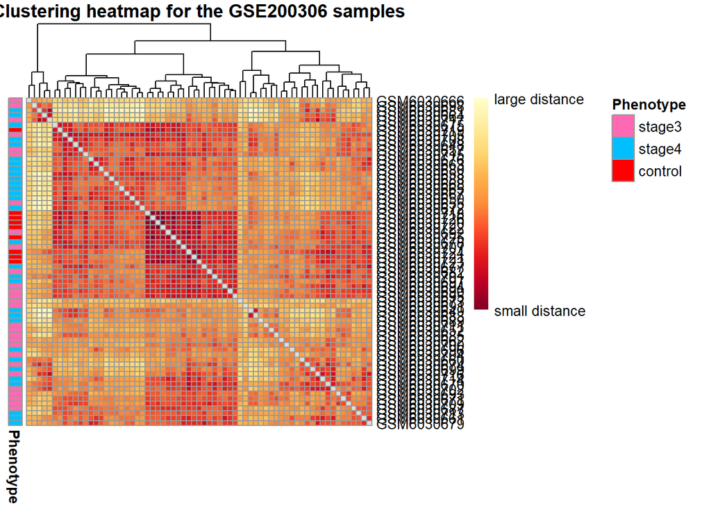

```r
annotation_for_heatmap <- data.frame(Phenotype = Biobase::pData(gset)$stages)
row.names(annotation_for_heatmap) <- row.names(pData(gset))

dists <- as.matrix(dist(t(GSE200306_exprs), method = "manhattan"))
rownames(dists) <- row.names(pData(gset))
hmcol <- rev(colorRampPalette(RColorBrewer::brewer.pal(9, "YlOrRd"))(255))
colnames(dists) <- NULL
diag(dists) <- NA
ann_colors <- list(
  Phenotype = c(stage3 = "hotpink", stage4 = "deepskyblue",control="red")
)
pheatmap(dists, col = (hmcol),
         annotation_row = annotation_for_heatmap,
         annotation_colors = ann_colors,
         legend = TRUE,
         treeheight_row = 0,
         legend_breaks = c(min(dists, na.rm = TRUE),
                           max(dists, na.rm = TRUE)),

         legend_labels = (c("small distance", "large distance")),
         main = "Clustering heatmap for the GSE200306 samples")
```

**box-and-whisker plot**

```r
dev.new(width=3+ncol(gset)/6, height=5)
ord <- order(gs)  # order samples by group
palette(c("#1B9E77", "#7570B3", "#E7298A", "#E6AB02", "#D95F02",
          "#66A61E", "#A6761D", "#B32424", "#B324B3", "#666666"))
par(mar=c(7,4,2,1))
title <- paste ("GSE200306", "/", annotation(gset), sep ="")
boxplot(ex[,ord], boxwex=0.6, notch=T, main=title, outline=FALSE, las=2, col=gs[ord])
legend("topleft", groups, fill=palette(), bty="n")
```

[output not shown]

**expression value distribution**

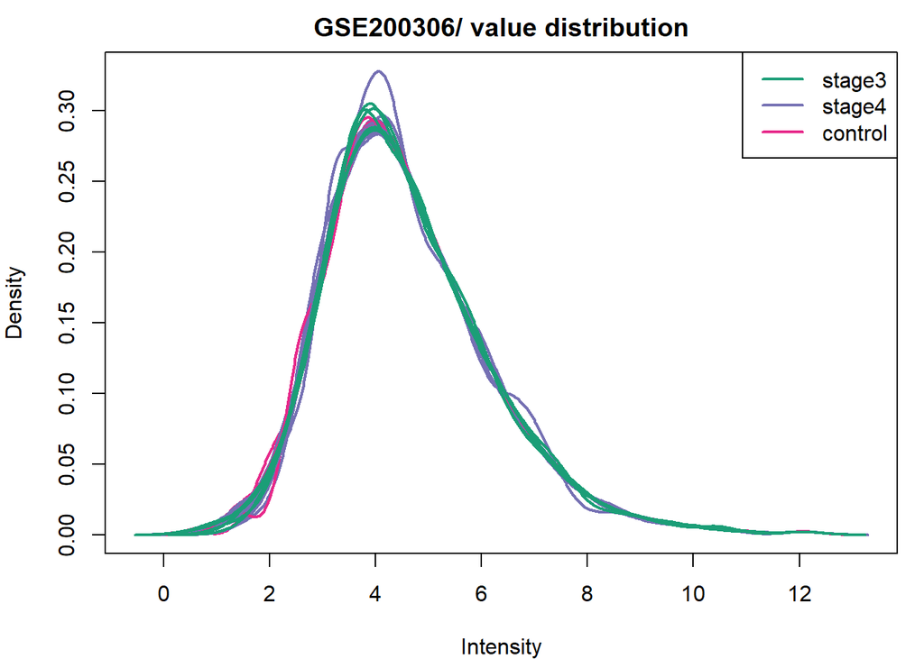

```r
par(mar=c(4,4,2,1))
title <- paste ("GSE200306", "/", annotation(gset), " value distribution", sep ="")
plotDensities(ex, group=gs, main=title, legend ="topright")
```

The distribution of expression values for all three groups (stage3, stage4, and control) appears to be right-skewed. This means that there are more genes with lower expression values than there are genes with higher expression values.

**DIFFERENTIAL GENE EXPRESSION ANALYSIS:**

Different types of statistical methods are employed to understand the distribution of gene expression data.

• linear model statistical testing (Limma) • multiple testing through FDR control

Compute statistics and table of top significant genes

HYPOTHESIS:

[output not shown]

The alternate hypothesis states that gene expression levels are different across the mentioned groups. So, to disapprove the null hypothesis based on p-value, we need to perform statistical tests. A library called LIMMA (Linear Models for Microarray Data) is used for this microarray dataset. It considers experimental design and addresses variance issues, offering more accurate results.

**fit linear model with limma**

```r
fit <- lmFit(gset, design)  # fit linear model


#set up contrasts of interest and recalculate model coefficients

cts <- paste(groups, c(tail(groups, -1), head(groups, 1)), sep="-")
cont.matrix <- makeContrasts(contrasts=cts, levels=design)
fit2<- contrasts.fit(fit, cont.matrix)

# compute statistics and table of top significant genes
fit2<- eBayes(fit2, 0.01)

#summary(decideTests(fit2))

tT2 <- topTable(fit2, adjust="fdr", sort.by="B",  number=Inf)

tT2sub <- subset(tT2, select=c("ID","adj.P.Val","P.Value","F","ORF","GB_ACC","SEQUENCE","SPOT_ID","stage3.stage4","stage4.control","control.stage3"))
sg<- tT2sub[tT2sub$adj.P.Val < 0.05, ]
```

significant genes with logFC values less than and greater than 1

```r
#stage3 vs stage4
sg34UP<- sg[sg$stage3.stage4> 1, ]
sg34DOWN <- sg[sg$stage3.stage4 < -1, ]
sg34<-rbind(sg34UP,sg34DOWN)
sg34_subset<-sg34[,1:9]
colnames(sg34_subset)[9] = "logFC"
```

```r
#stage3vs control
sg3cUP<-sg[sg$control.stage3>1,]
sg3cDOWN<-sg[sg$control.stage3< -1,]
sg3c<-rbind(sg3cUP,sg3cDOWN)
sg3c_subset <- cbind(sg3c[,1:8], sg3c[,10])
colnames(sg3c_subset)[9]="logFC"
```

```r
#stage4 vs control
sg4cUP<-sg[sg$stage4.control>1,]
sg4cDOWN<-sg[sg$stage4.control< -1,]
sg4c<-rbind(sg4cUP,sg4cDOWN)
sg4c_subset <- cbind(sg4c[,1:8], sg4c[,11])
colnames(sg4c_subset)[9]="logFC"
```

```r
siggenes<-rbind(sg34_subset,sg4c_subset,sg3c_subset)

write.csv(siggenes,file="cytoscapesiggenes.csv")

 my.symbols<-cat(rownames(siggenes), sep = "\n")
```

```
## CR1
## MME
## BST1
## SMAD5
## RORC
## FYN
## FKBP5
## NFATC3
## IL1RAP
## EGR1
## TRAF5
## CD9
## TGFBR2
## ZBTB16
## C1R
## POU2F2
## SYK
## TGFBI
## FCER1G
## MYD88
## IKZF1
## TNFSF11
## CD45RB
## PTPRC_all
## ICAM1
## SLAMF7
## IL18RAP
## CD45R0
## IL18RAP1
## FN1
## VCAM1
## POU2F21
## ITGB2
## SYK1
## MX1
## MSR1
## TGFBI1
## FCER1G1
## C1QB
## CYBB
## CD44
## TNFSF111
## FN11
## CD45RB1
## PTPRC_all1
## CD45R01
## CR11
## MME1
## BST11
## SMAD51
## RORC1
## FYN1
## FKBP51
## TRAF51
## CD91
## TGFBR21
## ZBTB161
## CX3CL1
```

**Visualize and quality control test results.**

Build histogram of P-values for all genes, Normal test assumption is that most genes are not differentially expressed.

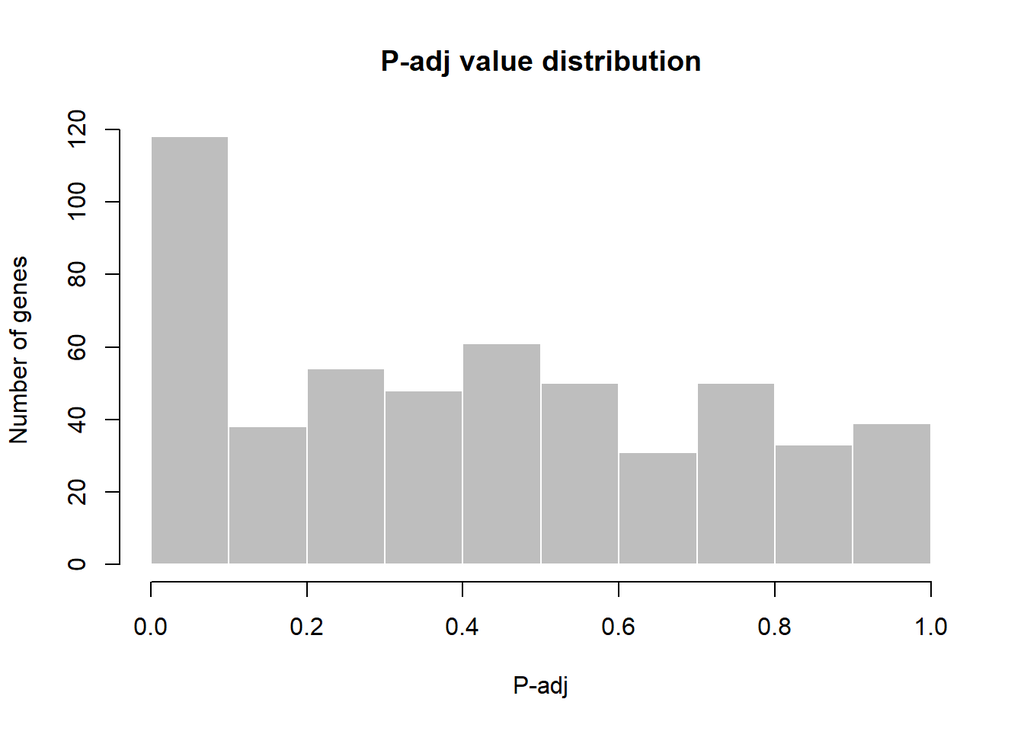

```r
tT2 <- topTable(fit2, adjust="fdr", sort.by="B", number=Inf)
hist(tT2$adj.P.Val, col = "grey", border = "white", xlab = "P-adj",
     ylab = "Number of genes", main = "P-adj value distribution")
```

**create Q-Q plot for t-statistic** A Q-Q plot is a graphical method used to assess whether the observed data follows a specific theoretical distribution, such as the normal distribution. This normal quantile-quantile (Q-Q) plot compares the quantiles of our data to the quantiles of a normal distribution. In this case, it compares the distribution of the moderate t-statistic obtained from a comparison of different stages and control samples to a normal distribution.

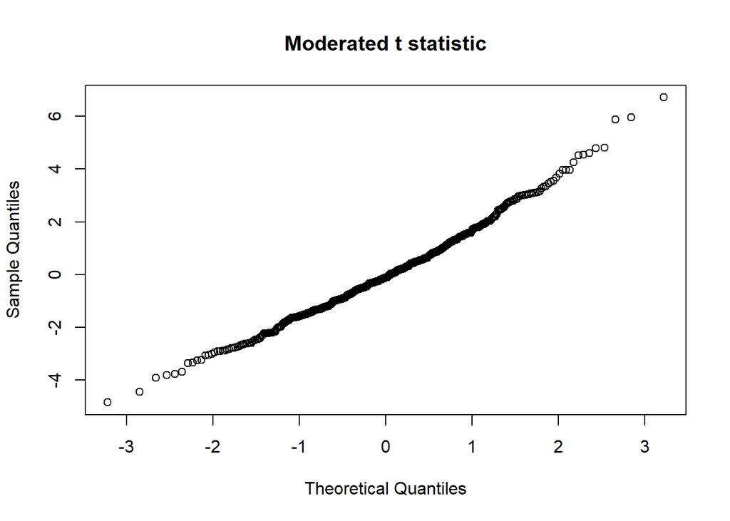

```r
t.good <- which(!is.na(fit2$F)) # filter out bad probes
qqt(fit2$t[t.good], fit2$df.total[t.good], main="Moderated t statistic")
```

Plots the quantiles of a data sample against the theoretical quantiles of distribution. This plot helps to assess the quality of the limma test results. Ideally, the points lie along a straight line, meaning that the values for moderated t-statistics computed during the test follow their theoretically predicted distribution.

```r
# summarize test results as "up", "down" or "not expressed"
dT <- decideTests(fit2, adjust.method="fdr", p.value=0.05, lfc=0)
```

**volcano plot (log P-value vs log fold change)**

The volcano plot gives the significantly expressed genes between stages that have log2FC values in the x-axis above 1 to be upregulated and below -1 to be downregulated. The -log10(p-value) indicates statistical significance. It represents the probability that the observed difference in expression between two groups is due to random chance. A lower p-value indicates a stronger significance.

```r
colnames(fit2) # list contrast names
```

```
## [1] "stage3-stage4"  "stage4-control" "control-stage3"
```

```r
ct <- 1   #stage3-stage4
ct2<-2#stage4-control
ct1<-3#control-stage3
```

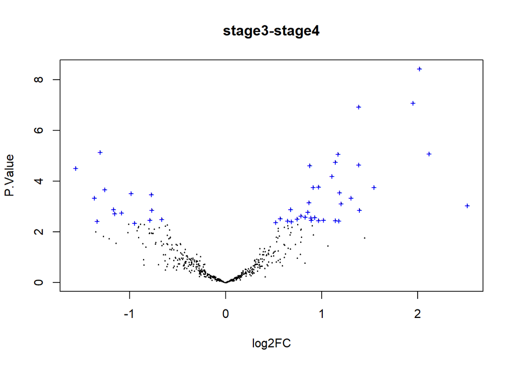

```r
#stage3 vs stage4
volcanoplot(fit2, coef=ct, main=colnames(fit2)[ct], pch=20,x = 'log2FC', y = 'P.Value',
            highlight=length(which(dT[,ct]!=0)), names=rep('+', nrow(fit2)))
```

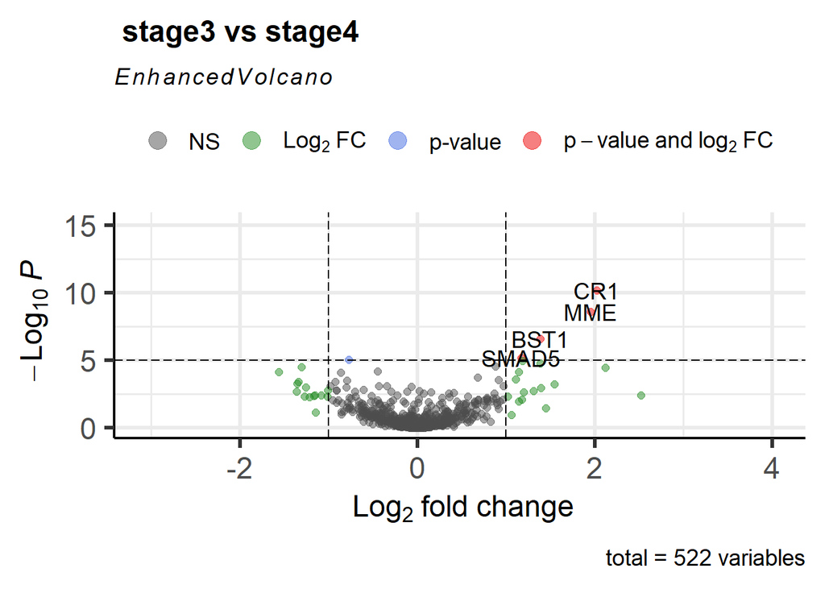

```r
EnhancedVolcano(tT2,
                lab = tT2$ID,
                x = 'stage3.stage4',
                title=" stage3 vs stage4",
                y = 'P.Value')
```

The enhanced volcano plot shows the significantly expressed genes whose log2FC value and -log10P value are above the threshold in red dots (CR1, MME, BST1, SMAD5) genes and are upregulated and those with only significant log2FC value in green dots.

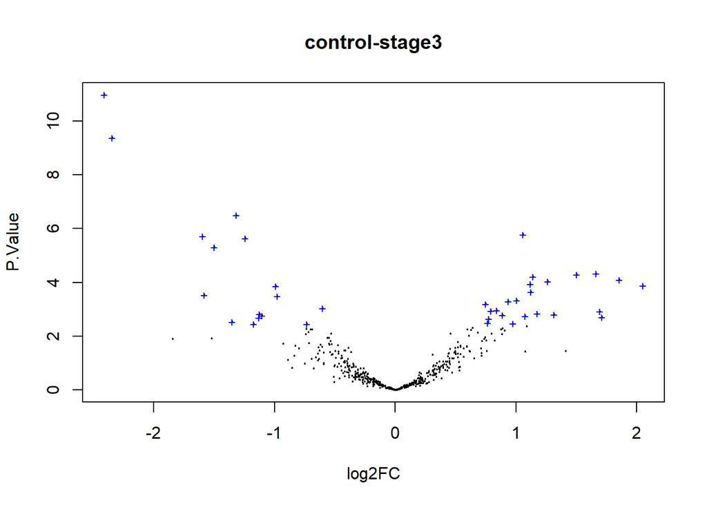

```r
#stage3 vs control

volcanoplot(fit2, coef=ct1, main=colnames(fit2)[ct1], pch=20,x='log2FC',y='P.Value',
            highlight=length(which(dT[,ct1]!=0)), names=rep('+', nrow(fit2)))
```

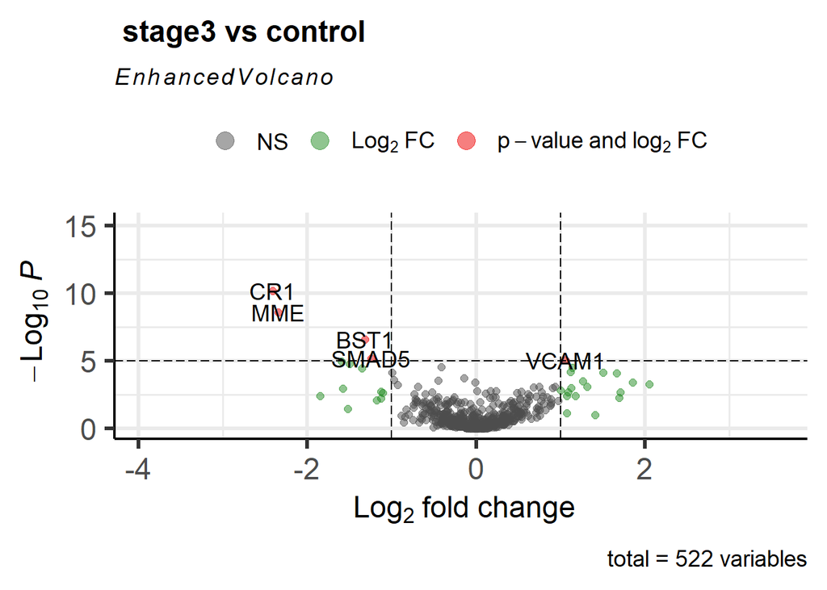

```r
EnhancedVolcano(tT2,
                lab = tT2$ID,
                x = 'control.stage3',
                title=" stage3 vs control",
                y = 'P.Value')
```

The enhanced volcano plot between stage 3 and control gives significantly differentiated genes with downregulated genes with significant log2FC value and -log10P value.

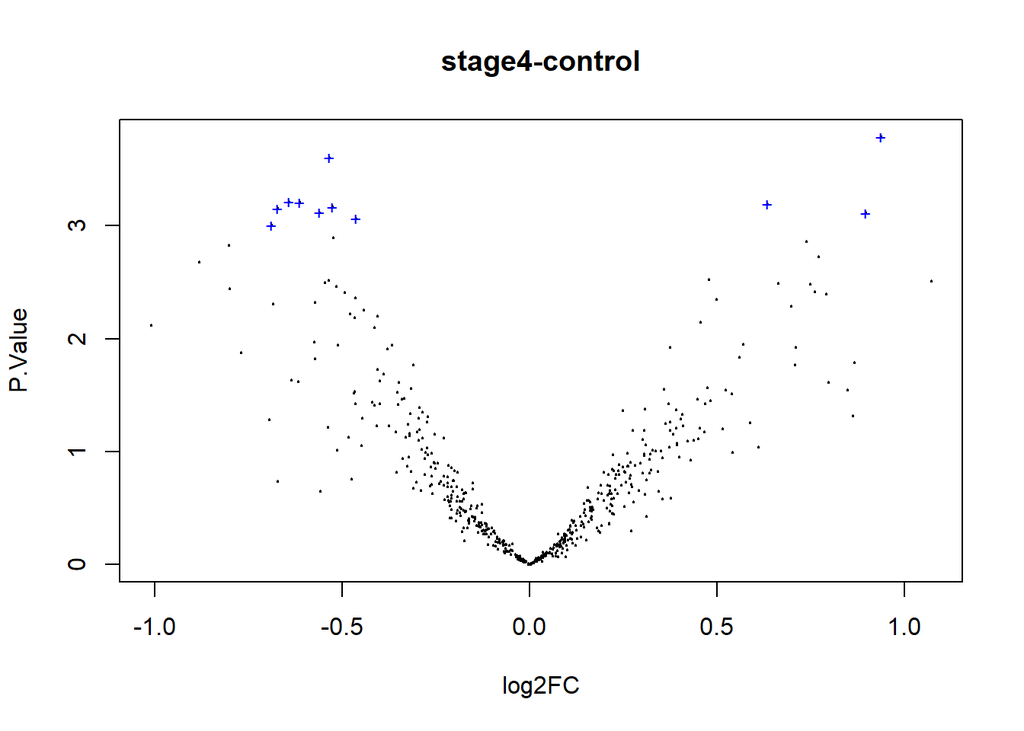

```r
#stage4 vs control
volcanoplot(fit2, coef=ct2, main=colnames(fit2)[ct2], pch=20,x = 'log2FC',y = 'P.Value',
            highlight=length(which(dT[,ct2]!=0)), names=rep('+', nrow(fit2)))
```

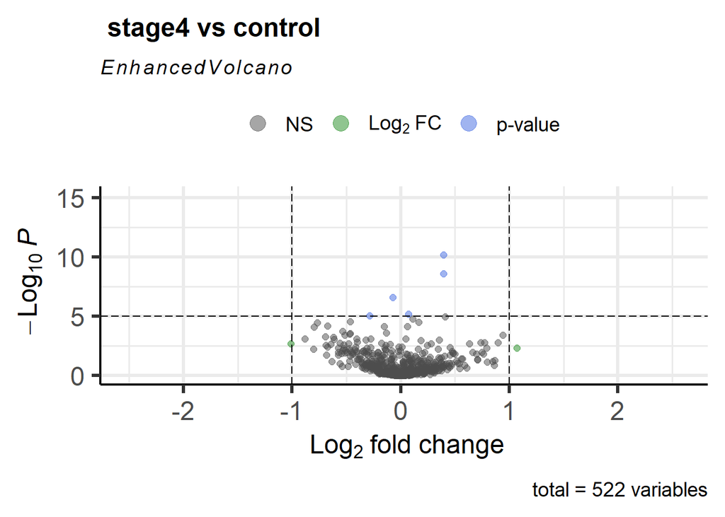

```r
EnhancedVolcano(tT2,
                lab = tT2$ID,
                x = 'stage4.control',
                title=" stage4 vs control",
                y = 'P.Value')
```